# Data Science

## 1. Import and aggregate data

### 1a. Collect information and Gather all fields you believe might cause avoidable delays

```python
import pandas as pd
import numpy as np
import matplotlib.pyplot as plt
import seaborn as sns
import warnings
warnings.filterwarnings('ignore')
```

```python
# Load datasets
ip_airlines = pd.read_excel('Z:\\DS\\Data_science_projects\\Sai\\Capstone2\\python\\Airlines.xlsx')
ip_airports = pd.read_excel('Z:\\DS\\Data_science_projects\\Sai\\Capstone2\\python\\airports.xlsx')
ip_runways = pd.read_excel('Z:\\DS\\Data_science_projects\\Sai\\Capstone2\\python\\runways.xlsx')
```

```python
ip_airlines.head(2)
```

|  | id | Airline | Flight | AirportFrom | AirportTo | DayOfWeek | Time | Length | Delay |
| --- | --- | --- | --- | --- | --- | --- | --- | --- | --- |
| 0 | 1 | CO | 269 | SFO | IAH | 3 | 15 | 205 | 1 |
| 1 | 2 | US | 1558 | PHX | CLT | 3 | 15 | 222 | 1 |

```python
ip_airports.head(2)
```

|  | id | ident | type | name | latitude_deg | longitude_deg | elevation_ft | continent | iso_country | iso_region | municipality | scheduled_service | gps_code | iata_code | local_code | home_link | wikipedia_link | keywords |
| --- | --- | --- | --- | --- | --- | --- | --- | --- | --- | --- | --- | --- | --- | --- | --- | --- | --- | --- |
| 0 | 6523 | 00A | heliport | Total Rf Heliport | 40.070801 | -74.933601 | 11.0 | NaN | US | US-PA | Bensalem | no | 00A | NaN | 00A | NaN | NaN | NaN |
| 1 | 323361 | 00AA | small_airport | Aero B Ranch Airport | 38.704022 | -101.473911 | 3435.0 | NaN | US | US-KS | Leoti | no | 00AA | NaN | 00AA | NaN | NaN | NaN |

```python
ip_runways.head(2)
```

|  | id | airport_ref | airport_ident | length_ft | width_ft | surface | lighted | closed | le_ident | le_latitude_deg | le_longitude_deg | le_elevation_ft | le_heading_degT | le_displaced_threshold_ft | he_ident | he_latitude_deg | he_longitude_deg | he_elevation_ft | he_heading_degT | he_displaced_threshold_ft |
| --- | --- | --- | --- | --- | --- | --- | --- | --- | --- | --- | --- | --- | --- | --- | --- | --- | --- | --- | --- | --- |
| 0 | 269408 | 6523 | 00A | 80.0 | 80.0 | ASPH-G | 1 | 0 | H1 | NaN | NaN | NaN | NaN | NaN | NaN | NaN | NaN | NaN | NaN | NaN |
| 1 | 255155 | 6524 | 00AK | 2500.0 | 70.0 | GRVL | 0 | 0 | N | NaN | NaN | NaN | NaN | NaN | S | NaN | NaN | NaN | NaN | NaN |

```python
# renaming columns for better understanding and consistency
ip_airlines.rename(columns={'Length':'Duration_min'}, inplace=True)
ip_airports.rename(columns={'id':'airport_ref'}, inplace=True)
ip_runways.rename(columns={'id':'runway_id'}, inplace=True)
```

```python
#checking shape for all datasets
print(ip_airlines.shape)
print(ip_airports.shape)
print(ip_runways.shape)
```

```
(518556, 9)
(73805, 18)
(43977, 20)
```

```python
# checking airports and runways data for important features which cause delays
print(ip_airlines.columns)
print(ip_airports.columns)
print(ip_runways.columns)
```

```
Index(['id', 'Airline', 'Flight', 'AirportFrom', 'AirportTo', 'DayOfWeek',
       'Time', 'Duration_min', 'Delay'],
      dtype='object')
Index(['airport_ref', 'ident', 'type', 'name', 'latitude_deg', 'longitude_deg',
       'elevation_ft', 'continent', 'iso_country', 'iso_region',
       'municipality', 'scheduled_service', 'gps_code', 'iata_code',
       'local_code', 'home_link', 'wikipedia_link', 'keywords'],
      dtype='object')
Index(['runway_id', 'airport_ref', 'airport_ident', 'length_ft', 'width_ft',
       'surface', 'lighted', 'closed', 'le_ident', 'le_latitude_deg',
       'le_longitude_deg', 'le_elevation_ft', 'le_heading_degT',
       'le_displaced_threshold_ft', 'he_ident', 'he_latitude_deg',
       'he_longitude_deg', 'he_elevation_ft', 'he_heading_degT',
       'he_displaced_threshold_ft'],
      dtype='object')
```

Below are the important features from each dataset, might cause avoidable delays in one dataset.

1) ip_airlines: except id all features are important 2) ip_airports: (id, iata_code): to link data to other datasets,(type): size of airport,  
(elevation_ft): higher altitudes affect weather & plane performance 3) ip_runways: (airport_ref): to link to the airport data,('length_ft', 'width_ft', 'surface'): determine area and surface type to tell quickness of landing/takeoff, ('lighted', 'closed'): reduces air traffic because of airport limitations which causes delays

```python
#Feature selection
ip_airlines.drop(columns=['id'],inplace=True)
ip_airports = ip_airports[['airport_ref', 'iata_code', 'type', 'elevation_ft']]
ip_runways = ip_runways[['runway_id', 'airport_ref', 'length_ft', 'width_ft', 'surface', 'lighted', 'closed']]
```

Dropping duplicates

```python
ip_airlines.drop_duplicates(inplace=True)
ip_airports.drop_duplicates(inplace=True)
ip_runways.drop_duplicates(inplace=True)

print(ip_airlines.shape)
print(ip_airports.shape)
print(ip_runways.shape)

#reseting index after dropping duplicates
ip_airlines.reset_index(drop=True, inplace=True)
ip_airports.reset_index(drop=True, inplace=True)
ip_runways.reset_index(drop=True, inplace=True)
```

```
(309346, 8)
(73805, 4)
(43977, 7)
```

Dropping Null values

```python
# checking null values in all datasets
print(ip_airlines.isnull().sum())
print(ip_airports.isnull().sum())
print(ip_runways.isnull().sum())
```

```
Airline         0
Flight          0
AirportFrom     0
AirportTo       0
DayOfWeek       0
Time            0
Duration_min    0
Delay           0
dtype: int64
airport_ref         0
iata_code       64645
type                0
elevation_ft    14122
dtype: int64
runway_id         0
airport_ref       0
length_ft       224
width_ft       2889
surface         457
lighted           0
closed            0
dtype: int64
```

```python
#checking percentage of null values in ip_runways
ip_runways.isnull().sum() * 100 / ip_runways.shape[0]
```

```
runway_id      0.000000
airport_ref    0.000000
length_ft      0.509357
width_ft       6.569343
surface        1.039180
lighted        0.000000
closed         0.000000
dtype: float64
```

```python
# Dropping null values as they are around than 5% of the data and we have enough data to train our model without them.
# we cant fill null values because length,width doesnt depend on any other features like lighted/closed/surface/num_runways.
ip_runways.dropna(inplace=True)
ip_runways.reset_index(drop=True, inplace=True)
ip_runways
```

|  | runway_id | airport_ref | length_ft | width_ft | surface | lighted | closed |
| --- | --- | --- | --- | --- | --- | --- | --- |
| 0 | 269408 | 6523 | 80.0 | 80.0 | ASPH-G | 1 | 0 |
| 1 | 255155 | 6524 | 2500.0 | 70.0 | GRVL | 0 | 0 |
| 2 | 254165 | 6525 | 2300.0 | 200.0 | TURF | 0 | 0 |
| 3 | 270932 | 6526 | 40.0 | 40.0 | GRASS | 0 | 0 |
| 4 | 322128 | 322127 | 1450.0 | 60.0 | Turf | 0 | 0 |
| ... | ... | ... | ... | ... | ... | ... | ... |
| 40927 | 235188 | 27242 | 10827.0 | 148.0 | CON | 1 | 0 |
| 40928 | 235186 | 27243 | 10499.0 | 148.0 | CON | 1 | 0 |
| 40929 | 235169 | 27244 | 8530.0 | 148.0 | CON | 1 | 0 |
| 40930 | 346789 | 346788 | 1800.0 | 15.0 | Turf | 0 | 0 |
| 40931 | 313663 | 313629 | 1713.0 | 82.0 | concrete | 0 | 0 |

40932 rows × 7 columns

```python
#checking percentage of null values in ip_airports
ip_airports.isnull().sum() * 100 / ip_airports.shape[0]
```

```
airport_ref      0.000000
iata_code       87.588917
type             0.000000
elevation_ft    19.134205
dtype: float64
```

```python
#checking for which airport types iata_code is missing
ip_airports.groupby('type')['iata_code'].count()
# iata_code is missing for mostly smaller size airport types like small_airport, heliport, seaplane_base which are around 3% of the data.
# skipping it for now
```

```
type
balloonport          0
closed             293
heliport            81
large_airport      448
medium_airport    4067
seaplane_base      149
small_airport     4122
Name: iata_code, dtype: int64
```

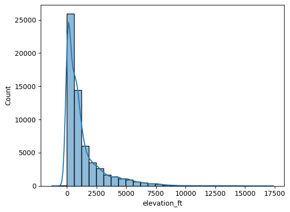

```python
import seaborn as sns
# checking distribution of elevation_ft
sns.histplot(ip_airports['elevation_ft'], bins=30, kde=True)
```

```python
# filling null values for elevation_ft as data is right skewed and we can use median to fill null values as its robust to outliers
ip_airports['elevation_ft'].fillna(ip_airports['elevation_ft'].median(), inplace=True)
```

Aggregating Runways data

```python
ip_runways.head(2)
```

|  | runway_id | airport_ref | length_ft | width_ft | surface | lighted | closed |
| --- | --- | --- | --- | --- | --- | --- | --- |
| 0 | 269408 | 6523 | 80.0 | 80.0 | ASPH-G | 1 | 0 |
| 1 | 255155 | 6524 | 2500.0 | 70.0 | GRVL | 0 | 0 |

```python
ip_runways_agg = ip_runways.groupby('airport_ref').agg({
    'runway_id': 'count',
    'length_ft': 'mean',
    'width_ft': 'mean',
    'lighted': 'max',
    'closed': 'max',
    'surface': 'first'
}).reset_index()
ip_runways_agg.rename(columns={'runway_id': 'num_runways'}, inplace=True)
ip_runways_agg.head(5)
```

|  | airport_ref | num_runways | length_ft | width_ft | lighted | closed | surface |
| --- | --- | --- | --- | --- | --- | --- | --- |
| 0 | 2 | 1 | 7080.0 | 200.0 | 0 | 0 | ASP |
| 1 | 3 | 1 | 7218.0 | 148.0 | 1 | 0 | ASP |
| 2 | 4 | 1 | 4593.0 | 98.0 | 0 | 0 | ASP |
| 3 | 5 | 1 | 3855.0 | 228.0 | 0 | 0 | GRS |
| 4 | 7 | 2 | 3266.5 | 250.0 | 0 | 0 | CON |

```python
ip_runways_agg.shape
```

```
(34773, 7)
```

Joining Airports and Runways aggregated data to get airport wise stats

```python
ip_airports_runways_agg = ip_airports.merge(ip_runways_agg, left_on='airport_ref', right_on='airport_ref', how='inner')
ip_airports_runways_agg.head(5)
```

|  | airport_ref | iata_code | type | elevation_ft | num_runways | length_ft | width_ft | lighted | closed | surface |
| --- | --- | --- | --- | --- | --- | --- | --- | --- | --- | --- |
| 0 | 6523 | NaN | heliport | 11.0 | 1 | 80.0 | 80.0 | 1 | 0 | ASPH-G |
| 1 | 6524 | NaN | small_airport | 450.0 | 1 | 2500.0 | 70.0 | 0 | 0 | GRVL |
| 2 | 6525 | NaN | small_airport | 820.0 | 1 | 2300.0 | 200.0 | 0 | 0 | TURF |
| 3 | 6526 | NaN | closed | 237.0 | 1 | 40.0 | 40.0 | 0 | 0 | GRASS |
| 4 | 322127 | NaN | small_airport | 1100.0 | 1 | 1450.0 | 60.0 | 0 | 0 | Turf |

```python
ip_airports_runways_agg.shape
```

```
(34773, 10)
```

```python
ip_airports_runways_agg.isnull().sum()
```

```
airport_ref         0
iata_code       28194
type                0
elevation_ft        0
num_runways         0
length_ft           0
width_ft            0
lighted             0
closed              0
surface             0
dtype: int64
```

### 1b. Scraping airlines data

```python
import requests
url_airlines = "https://en.wikipedia.org/wiki/List_of_airlines_of_the_United_States"
headers = {
    "User-Agent": "Mozilla/5.0 (Windows NT 10.0; Win64; x64) AppleWebKit/537.36 (KHTML, like Gecko) Chrome/91.0.4472.124 Safari/537.36"
}
response = requests.get(url_airlines, headers=headers)
tables = pd.read_html(response.text)
```

```python
len(tables) #total 21 tables present in the wiki-link
```

```
21
```

```python
ref_airline_exp = pd.concat([tables[0], tables[1], tables[2], tables[3]], ignore_index=True)
ref_airline_exp['Exp_Years'] = 2026 - ref_airline_exp['Founded']
ref_airline_exp=ref_airline_exp[['Airline', 'IATA', 'Founded', 'Exp_Years']]
ref_airline_exp.rename(columns={'Airline': 'Airline_name', 'IATA': 'iata_code'}, inplace=True)
ref_airline_exp
```

|  | Airline_name | iata_code | Founded | Exp_Years |
| --- | --- | --- | --- | --- |
| 0 | Alaska Air Group | AS | 1932.0 | 94.0 |
| 1 | Allegiant Air | G4 | 1997.0 | 29.0 |
| 2 | American Airlines | AA | 1926.0 | 100.0 |
| 3 | Avelo Airlines | XP | 1987.0 | 39.0 |
| 4 | Breeze Airways | MX | 2018.0 | 8.0 |
| ... | ... | ... | ... | ... |
| 81 | Superior Aviation | SO | 1979.0 | 47.0 |
| 82 | Talkeetna Air Taxi | NaN | 1947.0 | 79.0 |
| 83 | Tropic Ocean Airways | TI | 2009.0 | 17.0 |
| 84 | World Atlantic Airlines | WL | 2002.0 | 24.0 |
| 85 | XOJET Aviation LLC | NaN | 2006.0 | 20.0 |

86 rows × 4 columns

```python
ref_airline_exp.info()
```

```
<class 'pandas.core.frame.DataFrame'>
RangeIndex: 86 entries, 0 to 85
Data columns (total 4 columns):
 #   Column        Non-Null Count  Dtype
---  ------        --------------  -----
 0   Airline_name  86 non-null     object
 1   iata_code     57 non-null     object
 2   Founded       82 non-null     float64
 3   Exp_Years     82 non-null     float64
dtypes: float64(2), object(2)
memory usage: 2.8+ KB
```

Merging airlines_experience_df data with ip_airlines

```python
print(ip_airlines.head(2))
print(ref_airline_exp.head(2))
```

```
  Airline  Flight AirportFrom AirportTo  DayOfWeek  Time  Duration_min  Delay
0      CO     269         SFO       IAH          3    15           205      1
1      US    1558         PHX       CLT          3    15           222      1
       Airline_name iata_code  Founded  Exp_Years
0  Alaska Air Group        AS   1932.0       94.0
1     Allegiant Air        G4   1997.0       29.0
```

```python
ip_airlines_exp=ip_airlines.merge(ref_airline_exp[['Airline_name','iata_code','Exp_Years']], left_on='Airline', right_on='iata_code', how='left')
ip_airlines_exp.drop(columns=['iata_code'],inplace=True)
ip_airlines_exp.head(5)
```

|  | Airline | Flight | AirportFrom | AirportTo | DayOfWeek | Time | Duration_min | Delay | Airline_name | Exp_Years |
| --- | --- | --- | --- | --- | --- | --- | --- | --- | --- | --- |
| 0 | CO | 269 | SFO | IAH | 3 | 15 | 205 | 1 | NaN | NaN |
| 1 | US | 1558 | PHX | CLT | 3 | 15 | 222 | 1 | NaN | NaN |
| 2 | AA | 2400 | LAX | DFW | 3 | 20 | 165 | 1 | American Airlines | 100.0 |
| 3 | AA | 2466 | SFO | DFW | 3 | 20 | 195 | 1 | American Airlines | 100.0 |
| 4 | AS | 108 | ANC | SEA | 3 | 30 | 202 | 0 | Alaska Air Group | 94.0 |

```python
#checking null values after merging experience years with airlines data
print(ip_airlines_exp.shape)
print(ip_airlines_exp.isnull().sum())
ip_airlines_exp.isnull().sum() * 100 / ip_airlines_exp.shape[0]
```

```
(309346, 10)
Airline             0
Flight              0
AirportFrom         0
AirportTo           0
DayOfWeek           0
Time                0
Duration_min        0
Delay               0
Airline_name    53062
Exp_Years       53062
dtype: int64
```

```
Airline          0.000000
Flight           0.000000
AirportFrom      0.000000
AirportTo        0.000000
DayOfWeek        0.000000
Time             0.000000
Duration_min     0.000000
Delay            0.000000
Airline_name    17.152961
Exp_Years       17.152961
dtype: float64
```

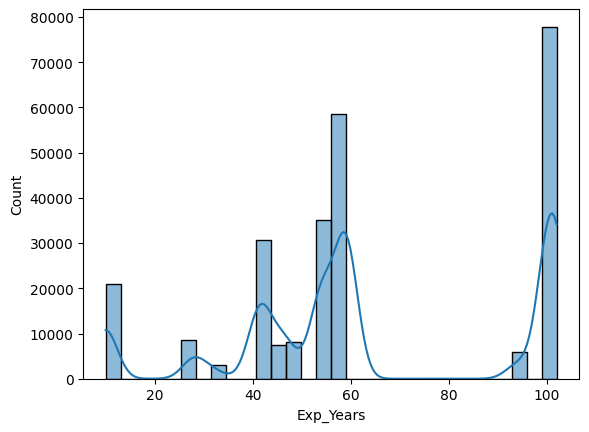

```python
# we can see that around 53 thousand airlines has missing experience years,its 17 % out of all data. hence cant be dropped.
# checking distribution of experience years of airlines
sns.histplot(ip_airlines_exp['Exp_Years'], bins=30, kde=True)
```

```python
# Distribution of Experience Years is not normally distributed so,
# we will replace missing values with median value because it wont be biased towards old or new airlines.
ip_airlines_exp['Exp_Years'].fillna(ip_airlines_exp['Exp_Years'].median(),inplace=True)
```

```python
ip_airlines_exp
```

|  | Airline | Flight | AirportFrom | AirportTo | DayOfWeek | Time | Duration_min | Delay | Airline_name | Exp_Years |
| --- | --- | --- | --- | --- | --- | --- | --- | --- | --- | --- |
| 0 | CO | 269 | SFO | IAH | 3 | 15 | 205 | 1 | NaN | 59.0 |
| 1 | US | 1558 | PHX | CLT | 3 | 15 | 222 | 1 | NaN | 59.0 |
| 2 | AA | 2400 | LAX | DFW | 3 | 20 | 165 | 1 | American Airlines | 100.0 |
| 3 | AA | 2466 | SFO | DFW | 3 | 20 | 195 | 1 | American Airlines | 100.0 |
| 4 | AS | 108 | ANC | SEA | 3 | 30 | 202 | 0 | Alaska Air Group | 94.0 |
| ... | ... | ... | ... | ... | ... | ... | ... | ... | ... | ... |
| 309341 | DL | 1002 | SLC | JFK | 5 | 1425 | 264 | 1 | Delta Air Lines | 102.0 |
| 309342 | US | 119 | KOA | PHX | 5 | 1425 | 349 | 1 | NaN | 59.0 |
| 309343 | UA | 86 | HNL | LAX | 5 | 1428 | 333 | 0 | United Airlines | 100.0 |
| 309344 | DL | 2354 | LAX | ATL | 5 | 1435 | 255 | 0 | Delta Air Lines | 102.0 |
| 309345 | B6 | 739 | JFK | PSE | 5 | 1439 | 223 | 1 | JetBlue | 28.0 |

309346 rows × 10 columns